# Available prediction performance metrics and indices

Adrian Correndo

2022-05-11

## Performance metrics available in *metrica*

The **metrica** package contains +40 functions. Two arguments are always required: `observed`(Oi; a.k.a. actual, measured, truth, target) and `predicted` (Pi; a.k.a. simulated, fitted) values. Also, there is an optional `data` arg. that allows to call an existing data frame containing both observed and predicted vectors.

Some functions, also require to define axis `orientation`, such as the slope of linear regression describing the bivariate scatter. Current included functions cover the world of “regression error” metrics (i.e. prediction performance for continuous variables). Classification error metrics coming soon.

Always keep in mind that predicted values should come from out-of-bag samples (unseen by training set) to avoid overestimation of prediction performance.

#

Metric

Definition

Details

Formula

A

`RSS`

Residual sum of squares (a.k.a. as sum of squares)

The sum of squared differences between predicted and observed values. It represents the base of many error metrics using squared scale such as the MSE

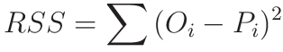

B

`TSS`

Total sum of squares

The sum of the squared differences between the observations and its mean. It is used as a reference error, for example, to estimate explained variance

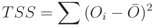

C

`var_u`

Sample variance, uncorrected

The mean of sum of squared differences between values of an `x` and its mean (divided by n, not n-1)

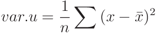

D

`uSD`

Sample standard deviation, uncorrected

The square root of the mean of sum of squared differences between values of an `x` and its mean (divided by n, not n-1)

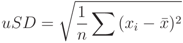

1

`B0`

Intercept of SMA regression

SMA is a symmetric linear regression (invariant results/interpretation to axis orientation) recommended to describe the bivariate scatter instead of OLS regression (classic linear model, which results vary with the axis orientation). B0 could be used to test agreement along with B1 (H0: B0 = 0, B1 = 1) . Warton et al. (2006)

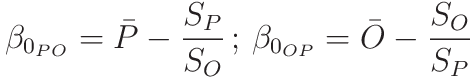

2

`B1`

Slope of SMA regression

SMA is a symmetric linear regression (invariant results/interpretation to axis orientation) recommended to describe the bivariate scatter instead of OLS regression (classic linear model, which results vary with the axis orientation). B1 could be used to test isometry of the PO scatter (H0: B1 = 1). B1 also represents the ratio of standard deviations (So and Sp). Warton et al. (2006)

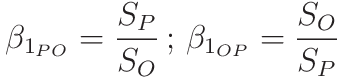

3

`r`

Pearson’s correlation coefficient

Strength of linear association between P and O. However, it measures “precision” but no accuracy. Kirch (2008)

4

`R2`

Coefficient of determination

Strength of linear association between P and O. However, it measures “precision” but no accuracy

5

`Xa`

Accuracy coefficient

Measures accuracy. Used to adjust the precision measured by `r` to estimate agreement

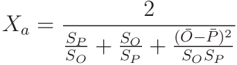

6

`CCC`

Concordance correlation coefficient

Tests agreement. It presents both precision (r) and accuracy (Xa) components. Easy to interpret. Lin (1989)

7

`MAE`

Mean Absolute Error

Measures both lack of accuracy and precision in absolute scale. It keeps the same units than the response variable. Less sensitive to outliers than the MSE or RMSE. Willmott & Matsuura (2005)

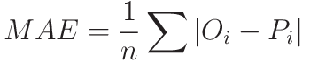

8

`RMAE`

Relative Mean Absolute Error

Normalizes the MAE with respect to the mean of observations

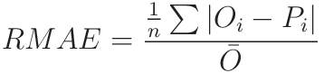

9

`MAPE`

Mean Absolute Percentage Error

Percentage units (independent scale). Easy to explain and to compare performance across models with different response variables. Asymmetric and unbounded.

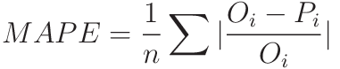

10

`SMAPE`

Symmetric Mean Absolute Percentage Error

SMAPE tackles the asymmetry issues of MAPE and includes lower (0%) and upper (200%) bounds. Makridakis (1993)

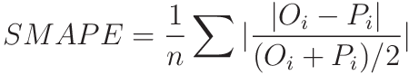

11

`RAE`

Relative Absolute Error

RAE normalizes MAE with respect to the total absolute error. Lower bound at 0 (perfect fit) and no upper bound (infinity)

12

`RSE`

Relative Squared Error

Proportion of the total sum of squares that corresponds to differences between predictions and observations (residual sum of squares)

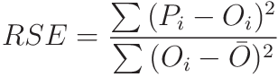

13

`MBE`

Mean Bias Error

Main bias error metric. Same units as the response variable. Related to differences between means of predictions and observations. Negative values indicate overestimation. Positive values indicate underestimation. Unbounded. Also known as average error. Janssen & Heuberger (1995)

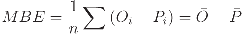

14

`PBE`

Percentage Bias Error

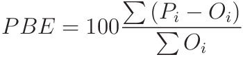

15

`PAB`

Percentage Additive Bias

Percentage of the MSE related to systematic additive issues on the predictions. Related to difference of the means of predictions and observations

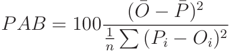

16

`PPB`

Percentage Proportional Bias

Percentage of the MSE related to systematic proportionality issues on the predictions. Related to slope of regression line describing the bivariate scatter

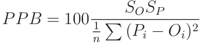

17

`MSE`

Mean Squared Error

Comprises both accuracy and precision. High sensitivity to outliers

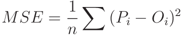

18

`RMSE`

Root Mean Squared Error

Comprises both precision and accuracy, has the same units than the variable of interest. Very sensitive to outliers

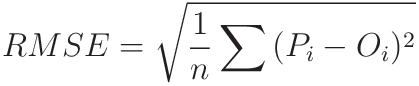

19

`RRMSE`

Relative Root Mean Squared Error

RMSE normalized by the mean of observations

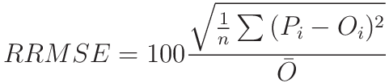

20

`RSR`

Root Mean Standard Deviation Ratio

RMSE normalized by the standard deviation of observations. Moriasi et al. (2007)

[figure not shown]

21

`iqRMSE`

Inter-quartile Normalized Root Mean Squared Error

RMSE normalized by the interquartile range length (between percentiles 25th and 75th)

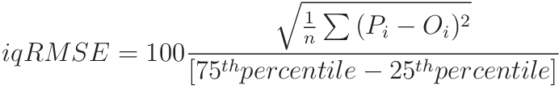

22

`MLA`

Mean Lack of Accuracy

Bias component of MSE decomposition. Correndo et al. (2021)

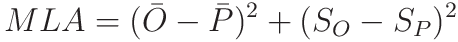

23

`MLP`

Mean Lack of Precision

Variance component of MSE decomposition. Correndo et al. (2021)

24

`PLA`

Percentage Lack of Accuracy

Percentage of the MSE related to lack of accuracy (systematic differences) on the predictions. Correndo et al. (2021)

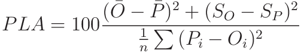

25

`PLP`

Percentage Lack of Precision

Percentage of the MSE related to lack of precision (unsystematic differences) on the predictions. Correndo et al. (2021)

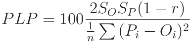

26

`SB`

Squared Bias

Additive bias component, MSE decomposition. Kobayashi and Salam (2000)

27

`SDSD`

Product of Standard Deviations

Proportional bias component, MSE decomposition. Kobayashi and Salam (2000)

28

`LCS`

Lack of Correlation

Random error component, MSE decomposition. Kobayashi and Salam (2000)

29

`Ue`

Random error proportion

The Ue estimates the proportion of the total sum of squares related to the random error (unsystematic error or variance) following the sum of squares decomposition suggested by Smith and Rose (1995) also known as Theil’s partial inequalities

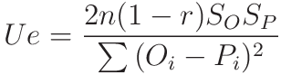

30

`Uc`

Lack of Consistency error proportion

The Uc estimates the proportion of the total sum of squares related to the lack of consistency (proportional bias) following the sum of squares decomposition suggested by Smith and Rose (1995) also known as Theil’s partial inequalities

31

`Ub`

Mean Bias error proportion

The Ub estimates the proportion of the total sum of squares related to the mean bias following the sum of squares decomposition suggested by Smith and Rose (1995) also known as Theil’s partial inequalities

32

`NSE`

Nash and Sutcliffe’s Model Efficiency

Model efficiency using squared residuals normalized by the variance of observations. Nash and Sutcliffe (1970)

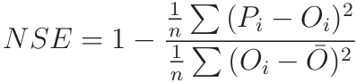

33

`E1`

Absolute Model Efficiency

Model efficiency. Modification of NSE using absolute residuals instead of squared residuals. Legates and McCabe (1999)

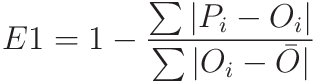

34

`Erel`

Relative Model Efficiency

Compared to the NSE, the Erel is suggested as more sensitive to systematic over- or under-predictions. Krause et al. (2005)

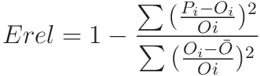

35

`KGE`

Kling-Gupta Model Efficiency

Model efficiency with accuracy, precision, and consistency components. Kling et al. (2012)

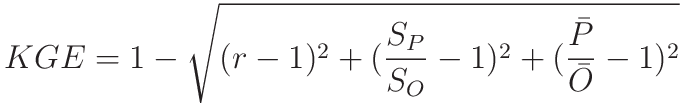

36

`d`

Index of Agreement

Measures accuracy and precision using squared residuals. Dimensionless (normalized). Bounded [0;1]. Asymmetric Willmott (1981)

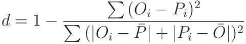

37

`d1`

Modified Index of Agreement

Measures accuracy and precision using absolute residuals(1). Dimensionless (normalized). Bounded [0;1]. Asymmetric Willmott et al. (1985)

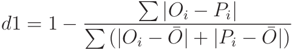

38

`d1r`

Refined Index of Agreement

Refines d1 by a modification on the denominator (potential error) to normalize absolute error. Willmott et al. (2012)

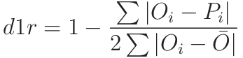

39

`RAC`

Robinson’s Agreement Coefficient